# ASC_TIMEcourse_limma_nucleolus_analysis

Sarah Hp

6/4/22

Calculate time effect for adipose stem cell differentiation to adipocytes via RNAseq. Previously Pro, D0, D1, D3, and D9 were sequenced in triplicate for two independent donors New samples: day15 floating and bulk RNAseq

```r
ous_dir = "C:/Users/sarahhp/OneDrive - Universitetet i Oslo/OUS"

read.geo <- function(file_url) {
  con <- gzcon(url(file_url))
  txt <- readLines(con)
  return(read.delim(textConnection(txt), skip=1, header=T))
}
```

# Load experiments and merge

or skip ahead to start analysis here ## Load D13 timecourse from GEO (with fractionally assigned multimapping alignments). Then format the table.

```r
d13_file = "https://www.ncbi.nlm.nih.gov/geo/download/?acc=GSE176020&format=file&file=GSE176020%5Fd13%5Frnaseq%2Emultim%2Ecounts%2Etxt%2Egz"
d13_tab = read.geo(d13_file)
colnames(d13_tab) =  gsub("output.01hisat.","", gsub(".sorted.bam","",colnames(d13_tab)))
#head(d13_tab) #table is messy so I won't print it here
```

Load file with sample info and match sample information to columns in FC table

```r
info_file = file.path(ous_dir,"D13rnaseqDec19/sample_info.csv")
d13_info = read.delim(info_file, header=TRUE, stringsAsFactors = FALSE, sep = ",")
#head(d13_info)

d13_info$sample_id = gsub("-",".", d13_info$Sequencing_name)

#remove unnecessary columns from d13_info
names(d13_info)[names(d13_info)=='Additional..fill.in.2.3.digits.code..max.5..construct.etc..'] = 'donor'
names(d13_info)[names(d13_info)=='Replicate..fill.in.number.'] = 'biorep'
names(d13_info)[names(d13_info)=='timept'] = 'time'
d13_info = d13_info[c('sample_id','time','donor','biorep','Tube.Label')]

#Checked that FC table and d13_info are in the same order
#colnames(d13_tab)
#d13_info$sample_id
```

## Load the Donor 7 timecourse:

And generate sample information from the bam file names

```r
d7_file = "https://www.ncbi.nlm.nih.gov/geo/download/?acc=GSE176020&format=file&file=GSE176020%5Fmar19%5Frnaseq%2Emultim%2Ecounts%2Etxt%2Egz"
d7_tab = read.geo(d7_file)
colnames(d7_tab) =  gsub("output.01hisat.","", gsub(".sorted.bam","",colnames(d7_tab)))
head(d7_tab)
```

```
##            Geneid                   Chr
## 1 ENSG00000223972     1;1;1;1;1;1;1;1;1
## 2 ENSG00000227232 1;1;1;1;1;1;1;1;1;1;1
## 3 ENSG00000278267                     1
## 4 ENSG00000243485             1;1;1;1;1
## 5 ENSG00000284332                     1
## 6 ENSG00000237613             1;1;1;1;1
##                                                               Start
## 1             11869;12010;12179;12613;12613;12975;13221;13221;13453
## 2 14404;15005;15796;16607;16858;17233;17606;17915;18268;24738;29534
## 3                                                             17369
## 4                                     29554;30267;30564;30976;30976
## 5                                                             30366
## 6                                     34554;35245;35277;35721;35721
##                                                                 End
```

[output cut: 27 more lines]

```r
#Remove the file system artefacts from the count column names to create a list of the libraries:
sample_id = grep("[[:digit:]]",colnames(d7_tab), value = T)
sample_id
```

```
##  [1] "1.KD4NT_S1"   "10.P6D3_S10"  "11.P6D9_S11"  "12.KD3NT_S12" "13.P8D0_S13"
##  [6] "14.P8D1_S14"  "15.P8D3_S15"  "16.P8D9_S16"  "2.KD5NT_S2"   "3.P5D0_S3"
## [11] "4.P5D1_S4"    "5.P5D3_S5"    "6.P5D9_S6"    "7.KD6NT_S7"   "8.P6D0_S8"
## [16] "9.P6D1_S9"
```

```r
#Next create a sample table with information about samples and time points taken from the filenames.
Tube.Label = gsub("\\..*_S[[:digit:]]+", "", sample_id)
time = gsub(".*(KD|P)[43586]D?", "", gsub("_S.*","",sample_id))
time = factor(gsub("NT","-2",time)) #match factors
biorep = gsub(".*\\.(KD|P)", "P", gsub("(D[0139]|NT)_S.*","",sample_id))
biorep =gsub("P3","P8",biorep) #fix biorep error
donor = rep("D07-G", 16)

d7_info = data.frame(sample_id,time,donor,biorep,Tube.Label)
d7_info
```

```
##       sample_id time donor biorep Tube.Label
## 1    1.KD4NT_S1   -2 D07-G     P4          1
## 2   10.P6D3_S10    3 D07-G     P6         10
## 3   11.P6D9_S11    9 D07-G     P6         11
## 4  12.KD3NT_S12   -2 D07-G     P8         12
## 5   13.P8D0_S13    0 D07-G     P8         13
## 6   14.P8D1_S14    1 D07-G     P8         14
## 7   15.P8D3_S15    3 D07-G     P8         15
## 8   16.P8D9_S16    9 D07-G     P8         16
## 9    2.KD5NT_S2   -2 D07-G     P5          2
## 10    3.P5D0_S3    0 D07-G     P5          3
## 11    4.P5D1_S4    1 D07-G     P5          4
## 12    5.P5D3_S5    3 D07-G     P5          5
## 13    6.P5D9_S6    9 D07-G     P5          6
## 14   7.KD6NT_S7   -2 D07-G     P6          7
## 15    8.P6D0_S8    0 D07-G     P6          8
## 16    9.P6D1_S9    1 D07-G     P6          9
```

## Load New Samples (D15)

FYI this file includes RNAseq from a different project; we’ll filter that out later

```r
d15_file = file.path(ous_dir, "Feb22_RNAseq/02featureCounts/late_adipo_feb22.counts")
day15_tab = read.delim(d15_file, skip=1,header=T, stringsAsFactors = F)
colnames(day15_tab) = gsub("output.01hisat.","", gsub(".sorted.bam","",colnames(day15_tab)))
colnames(day15_tab)
```

```
##  [1] "Geneid"       "Chr"          "Start"        "End"          "Strand"
##  [6] "Length"       "1.21405_S22"  "2.21406_S30"  "3.21407_S38"  "4.21408_S45"
## [11] "5.21409_S52"  "6.21410_S1"   "7.21411_S8"   "8.21412_S15"  "9.21413_S23"
## [16] "10.21414_S31" "11.21415_S39" "12.21416_S46" "13.21417_S53" "14.21418_S2"
## [21] "15.21419_S9"  "16.21420_S16" "17.21421_S24" "18.21422_S32" "19.21423_S40"
## [26] "20.21424_S47" "21.21425_S54" "22.21426_S3"  "23.21427_S10" "24.21428_S17"
```

```r
day15_info = read.delim(file.path(ous_dir, "Feb22_RNAseq/late_adipo_sample_info.txt"),
                header=T)
day15_info$sample_id = gsub("-",".", day15_info$sample_id)
day15_info$time = factor(gsub("D","", day15_info$time))
day15_info$donor = gsub("D07G","D07-G", gsub("D13A","D13-A", day15_info$donor))
colnames(day15_info) = gsub("rep", "biorep", colnames(day15_info))
#use cell_type column as experiment delimiter
colnames(day15_info) = gsub("cell_type", "exp", colnames(day15_info))

day15_info = day15_info[!(colnames(day15_info) %in% c("bio.condition","researcher"))]

colnames(day15_info); day15_info$sample_id
```

```
## [1] "time"       "biorep"     "exp"        "construct"  "donor"
## [6] "separation" "sample_id"
```

```
##  [1] "1.21405_S22"  "2.21406_S30"  "3.21407_S38"  "4.21408_S45"  "5.21409_S52"
##  [6] "6.21410_S1"   "7.21411_S8"   "8.21412_S15"  "9.21413_S23"  "10.21414_S31"
## [11] "11.21415_S39" "12.21416_S46" "13.21417_S53" "14.21418_S2"  "15.21419_S9"
## [16] "16.21420_S16" "17.21421_S24" "18.21422_S32" "19.21423_S40" "20.21424_S47"
## [21] "21.21425_S54" "22.21426_S3"  "23.21427_S10" "24.21428_S17"
```

Edits to day15 file to fit: - remove D from time; add dash to donor - change column names: rep to biorep; cell_type to exp - remove researcher, bio.condition

## Merge read counts and sample info

Merging the fc tables directly

```r
early = merge(d13_tab, d7_tab)
colnames(early); dim(early)
```

```
##  [1] "Geneid"           "Chr"              "Start"            "End"
##  [5] "Strand"           "Length"           "6.19190_S20"      "7.19191_S1"
##  [9] "8.19192_S3"       "9.19193_S6"       "10.19194_S9"      "11.19195_S12"
## [13] "12.19196_S15"     "13.19197_S18"     "14.19198_S21"     "15.19199_S2"
## [17] "1.19200_S5"       "2.19201_S8"       "3.19202_S11"      "4.19203_S14"
## [21] "5.19204_S17"      "20.S2.KD5NT_S16"  "21.S7.KD6NT_S19"  "22.S12.KD3NT_S22"
## [25] "1.KD4NT_S1"       "10.P6D3_S10"      "11.P6D9_S11"      "12.KD3NT_S12"
## [29] "13.P8D0_S13"      "14.P8D1_S14"      "15.P8D3_S15"      "16.P8D9_S16"
## [33] "2.KD5NT_S2"       "3.P5D0_S3"        "4.P5D1_S4"        "5.P5D3_S5"
## [37] "6.P5D9_S6"        "7.KD6NT_S7"       "8.P6D0_S8"        "9.P6D1_S9"
```

```
## [1] 58735    40
```

```r
#Add experiment separator
d13_info$exp = 2
d7_info$exp = 1
colnames(d13_info)
```

```
## [1] "sample_id"  "time"       "donor"      "biorep"     "Tube.Label"
## [6] "exp"
```

```r
colnames(d7_info)
```

```
## [1] "sample_id"  "time"       "donor"      "biorep"     "Tube.Label"
## [6] "exp"
```

```r
early_info = rbind(d13_info, d7_info)
early_info$construct = "native"
early_info$separation = "bulk"

early_info = early_info[colnames(early_info) != "Tube.Label"]

table(paste(early_info$time, early_info$donor, early_info$exp))
```

```
##
## -2 D07-G 1 -2 D07-G 2 -2 D13-A 2  0 D07-G 1  0 D13-A 2  1 D07-G 1  1 D13-A 2
##          4          3          3          3          3          3          3
## 15 D07-G 2 15 D13-A 2  3 D07-G 1  3 D13-A 2  9 D07-G 1  9 D13-A 2
##          2          2          3          3          3          3
```

Merge sample information for D7 and d13; remove tube.label column and add columns construct=native and separation=bulk. Also add exp column; since d7 and d13 have overlapping samples

Merging in day15 now

```r
whole = merge(early, day15_tab)
dim(whole)
```

```
## [1] 58735    64
```

```r
whole_info = rbind(early_info, day15_info)
str(whole_info); tail(whole_info)
```

```
## 'data.frame':    62 obs. of  7 variables:
##  $ sample_id : chr  "6.19190_S20" "7.19191_S1" "8.19192_S3" "9.19193_S6" ...
##  $ time      : chr  "-2" "0" "1" "3" ...
##  $ donor     : chr  "D13-A" "D13-A" "D13-A" "D13-A" ...
##  $ biorep    : chr  "7" "7" "7" "7" ...
##  $ exp       : chr  "2" "2" "2" "2" ...
##  $ construct : chr  "native" "native" "native" "native" ...
##  $ separation: chr  "bulk" "bulk" "bulk" "bulk" ...
```

```
##       sample_id time donor biorep    exp construct separation
## 57 19.21423_S40   15 D07-G     P7 native    native       bulk
## 58 20.21424_S47   15 D07-G   P8_2 native    native       bulk
## 59 21.21425_S54   15 D07-G   P8_1 native    native       bulk
## 60  22.21426_S3   15 D13-A     P7 native    native       bulk
## 61 23.21427_S10   15 D13-A     P6 native    native       bulk
## 62 24.21428_S17   15 D13-A     P7 native    native       bulk
```

Save combined read counts so we don’t need to do this again.

```r
write.table(whole, file.path(ous_dir, "Feb22_RNAseq/03limma/late_adipo_and_D7&D13_native_rnaseq.counts"), sep="\t", row.names = F)
write.table(whole_info, file.path(ous_dir, "Feb22_RNAseq/03limma/late_adipo_and_D7&D13_native_rnaseq_info.tab"), sep="\t", row.names = F)
```

## Start Analysis Here

Load combined read counts from the previous analysis

```r
whole = read.delim(file.path(ous_dir, "Feb22_RNAseq/03limma/late_adipo_and_D7&D13_native_rnaseq.counts"), sep="\t", check.names = F )
whole_info = read.delim(file.path(ous_dir, "Feb22_RNAseq/03limma/late_adipo_and_D7&D13_native_rnaseq_info.tab"), sep="\t")
whole_info$donor = gsub("D13A","D13-A",whole_info$donor)
```

## Make DGE object

remove additional samples.

```r
whole_info$time.donor = paste(whole_info$time, whole_info$donor, sep=".")
whole_info$group = paste(whole_info$time.donor, whole_info$separation, sep=".")

whole_ob = DGEList(counts=data.matrix(whole[grep("[[:digit:]]", colnames(whole))]),
                   genes= whole[c("Geneid", "Length")], samples = whole_info)
rownames(whole_ob$counts) = whole_ob$genes$Geneid
summary (whole_ob)
```

```
##         Length  Class      Mode
## counts  3641570 -none-     numeric
## samples      11 data.frame list
## genes         2 data.frame list
```

```r
#Remove uncultured mature adipocytes from tissue extract
series_ob = whole_ob[,!(whole_ob$samples$exp == 2 & whole_ob$samples$time == 15)]
table(paste(series_ob$samples$group, whole_ob$samples$exp))
```

```
##
##          -2.D07-G.bulk 1          -2.D07-G.bulk 2          -2.D13-A.bulk 2
##                        2                        5                        3
##     -2.D13-A.bulk native           0.D07-G.bulk 1           0.D13-A.bulk 2
##                        1                        3                        3
##      0.D13-A.bulk native           1.D07-G.bulk 1           1.D13-A.bulk 2
##                        1                        3                        3
##      1.D13-A.bulk native          15.D07-G.bulk 1       15.D07-G.bulk APEX
##                        1                        4                        2
##     15.D07-G.bulk native   15.D07-G.floating APEX     15.D13-A.bulk native
##                        3                        3                        3
##   15.D13-A.floating APEX 15.D13-A.floating native       21.D07-G.bulk APEX
##                        1                        2                        6
##           3.D07-G.bulk 1           3.D07-G.bulk 2           3.D13-A.bulk 2
##                        2                        1                        3
##      3.D13-A.bulk native           9.D07-G.bulk 1           9.D07-G.bulk 2
##                        1                        2                        1
##           9.D13-A.bulk 2
##                        3
```

```r
#remove samples from other project
series_ob = series_ob[,series_ob$samples$construct == "native"]

#Check column names are the same
series_ob$samples
```

```
##                              group lib.size norm.factors        sample_id time
## 6.19190_S20          -2.D13-A.bulk 43343287            1      6-19190_S20   -2
## 7.19191_S1            0.D13-A.bulk 53954863            1       7-19191_S1    0
## 8.19192_S3            1.D13-A.bulk 44816024            1       8-19192_S3    1
## 9.19193_S6            3.D13-A.bulk 27650074            1       9-19193_S6    3
## 10.19194_S9           9.D13-A.bulk 33681648            1      10-19194_S9    9
## 11.19195_S12         -2.D13-A.bulk 44069380            1     11-19195_S12   -2
## 12.19196_S15          0.D13-A.bulk 33748947            1     12-19196_S15    0
## 13.19197_S18          1.D13-A.bulk 35268416            1     13-19197_S18    1
## 14.19198_S21          3.D13-A.bulk 38990845            1     14-19198_S21    3
## 15.19199_S2           9.D13-A.bulk 31648240            1      15-19199_S2    9
## 1.19200_S5           -2.D13-A.bulk 24715231            1       1-19200_S5   -2
## 2.19201_S8            0.D13-A.bulk 25887790            1       2-19201_S8    0
## 3.19202_S11           1.D13-A.bulk 67946021            1      3-19202_S11    1
## 4.19203_S14           3.D13-A.bulk 51335376            1      4-19203_S14    3
## 5.19204_S17           9.D13-A.bulk 41570892            1      5-19204_S17    9
## 20.S2.KD5NT_S16      -2.D07-G.bulk 28227567            1  20-S2-KD5NT_S16   -2
## 21.S7.KD6NT_S19      -2.D07-G.bulk 30639099            1  21-S7-KD6NT_S19   -2
## 22.S12.KD3NT_S22     -2.D07-G.bulk 39314312            1 22-S12-KD3NT_S22   -2
## 1.KD4NT_S1           -2.D07-G.bulk 40875335            1       1.KD4NT_S1   -2
## 10.P6D3_S10           3.D07-G.bulk 37487858            1      10.P6D3_S10    3
## 11.P6D9_S11           9.D07-G.bulk 45348216            1      11.P6D9_S11    9
## 12.KD3NT_S12         -2.D07-G.bulk 52250725            1     12.KD3NT_S12   -2
## 13.P8D0_S13           0.D07-G.bulk 50473193            1      13.P8D0_S13    0
## 14.P8D1_S14           1.D07-G.bulk 37355443            1      14.P8D1_S14    1
## 15.P8D3_S15           3.D07-G.bulk 36821008            1      15.P8D3_S15    3
## 16.P8D9_S16           9.D07-G.bulk 25192201            1      16.P8D9_S16    9
## 2.KD5NT_S2           -2.D07-G.bulk 39256967            1       2.KD5NT_S2   -2
## 3.P5D0_S3             0.D07-G.bulk 35885732            1        3.P5D0_S3    0
## 4.P5D1_S4             1.D07-G.bulk 44499333            1        4.P5D1_S4    1
## 5.P5D3_S5             3.D07-G.bulk 45252924            1        5.P5D3_S5    3
## 6.P5D9_S6             9.D07-G.bulk 38835735            1        6.P5D9_S6    9
## 7.KD6NT_S7           -2.D07-G.bulk 37829067            1       7.KD6NT_S7   -2
## 8.P6D0_S8             0.D07-G.bulk 38988386            1        8.P6D0_S8    0
## 9.P6D1_S9             1.D07-G.bulk 40833777            1        9.P6D1_S9    1
## 13.21417_S53     15.D07-G.floating 39520835            1     13.21417_S53   15
## 14.21418_S2      15.D07-G.floating 43198916            1      14.21418_S2   15
## 15.21419_S9      15.D07-G.floating 53192791            1      15.21419_S9   15
## 16.21420_S16     15.D13-A.floating 58757001            1     16.21420_S16   15
## 17.21421_S24     15.D13-A.floating 64220795            1     17.21421_S24   15
```

[output cut: 39 more lines]

```
## 7.KD6NT_S7       D07-G     P6      1    native       bulk   -2.D07-G
## 8.P6D0_S8        D07-G     P6      1    native       bulk    0.D07-G
## 9.P6D1_S9        D07-G     P6      1    native       bulk    1.D07-G
## 13.21417_S53     D07-G     P6 native    native   floating   15.D07-G
## 14.21418_S2      D07-G   P8_1 native    native   floating   15.D07-G
## 15.21419_S9      D07-G   P8_2 native    native   floating   15.D07-G
## 16.21420_S16     D13-A   P6_1 native    native   floating   15.D13-A
## 17.21421_S24     D13-A   P6_2 native    native   floating   15.D13-A
## 18.21422_S32     D13-A     P7 native    native   floating   15.D13-A
## 19.21423_S40     D07-G     P7 native    native       bulk   15.D07-G
## 20.21424_S47     D07-G   P8_2 native    native       bulk   15.D07-G
## 21.21425_S54     D07-G   P8_1 native    native       bulk   15.D07-G
## 22.21426_S3      D13-A     P7 native    native       bulk   15.D13-A
## 23.21427_S10     D13-A     P6 native    native       bulk   15.D13-A
## 24.21428_S17     D13-A     P7 native    native       bulk   15.D13-A
```

```r
colnames(series_ob)
```

```
##  [1] "6.19190_S20"      "7.19191_S1"       "8.19192_S3"       "9.19193_S6"
##  [5] "10.19194_S9"      "11.19195_S12"     "12.19196_S15"     "13.19197_S18"
##  [9] "14.19198_S21"     "15.19199_S2"      "1.19200_S5"       "2.19201_S8"
## [13] "3.19202_S11"      "4.19203_S14"      "5.19204_S17"      "20.S2.KD5NT_S16"
## [17] "21.S7.KD6NT_S19"  "22.S12.KD3NT_S22" "1.KD4NT_S1"       "10.P6D3_S10"
## [21] "11.P6D9_S11"      "12.KD3NT_S12"     "13.P8D0_S13"      "14.P8D1_S14"
## [25] "15.P8D3_S15"      "16.P8D9_S16"      "2.KD5NT_S2"       "3.P5D0_S3"
## [29] "4.P5D1_S4"        "5.P5D3_S5"        "6.P5D9_S6"        "7.KD6NT_S7"
## [33] "8.P6D0_S8"        "9.P6D1_S9"        "13.21417_S53"     "14.21418_S2"
## [37] "15.21419_S9"      "16.21420_S16"     "17.21421_S24"     "18.21422_S32"
## [41] "19.21423_S40"     "20.21424_S47"     "21.21425_S54"     "22.21426_S3"
## [45] "23.21427_S10"     "24.21428_S17"
```

## Initial Plots

Everything looks good. 1. MDSplot separates timepoints well 2. the RLE plot shows that median counts between libraries are 0, meaning library size and distribution is similar between libraries. Therefore normalisation between experiments is not necessary.

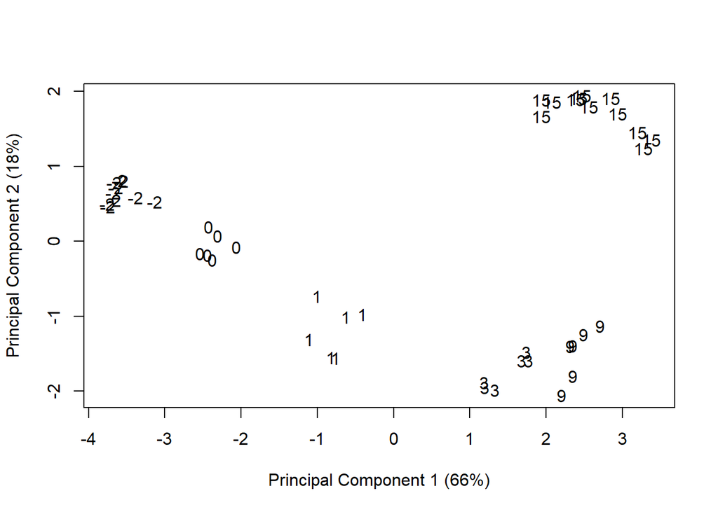

```r
plotMDS(series_ob, labels = series_ob$samples$time, gene.selection = "common")
```

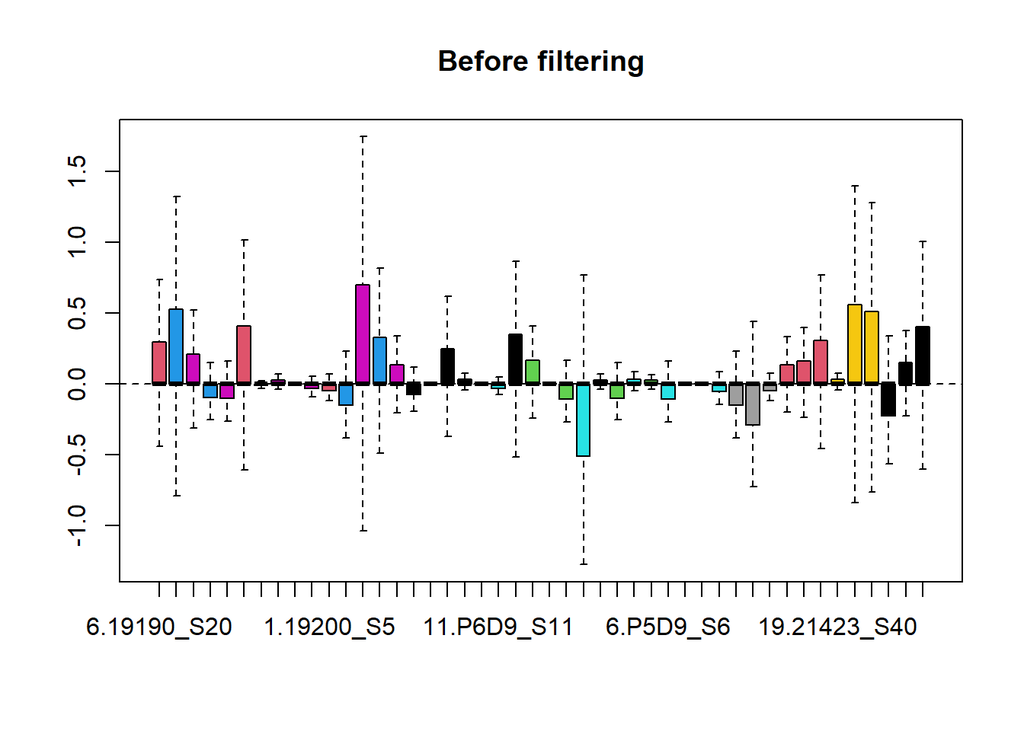

```r
plotRLE(series_ob$counts, outline=FALSE, col=series_ob$samples$group, main="Before filtering")
```

## Filtering

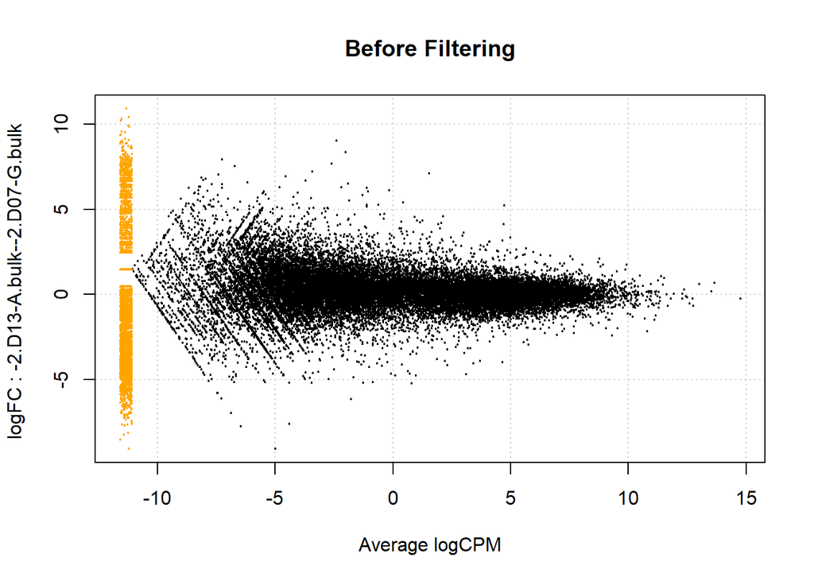

```r
plotSmear(series_ob, main = "Before Filtering")
```

```r
dim(series_ob)
```

```
## [1] 58735    46
```

```r
filt_series = series_ob[filterByExpr(series_ob),, keep.lib.sizes=FALSE]
dim(filt_series) #21174 genes kept (about 1k more genes that the timecourse to day9)
```

```
## [1] 21174    46
```

```r
#The filter is approxiamtely 10/ libsize in millions
10/(median(series_ob$samples$lib.size)/1000000) #0.245 minimum CPM
```

```
## [1] 0.2447707
```

```r
#sanity check that gene_names match up
filt_series$counts[filt_series$genes$Geneid == "ENSG00000228630",] #HOTAIR
```

```
##      6.19190_S20       7.19191_S1       8.19192_S3       9.19193_S6
##            67.00            60.00            61.00            26.00
##      10.19194_S9     11.19195_S12     12.19196_S15     13.19197_S18
##            18.00            39.00            52.00            36.00
##     14.19198_S21      15.19199_S2       1.19200_S5       2.19201_S8
##            41.00            15.00            18.00            46.00
##      3.19202_S11      4.19203_S14      5.19204_S17  20.S2.KD5NT_S16
##           105.00            37.00            12.00           200.00
##  21.S7.KD6NT_S19 22.S12.KD3NT_S22       1.KD4NT_S1      10.P6D3_S10
##           251.90           313.00           276.00           325.00
##      11.P6D9_S11     12.KD3NT_S12      13.P8D0_S13      14.P8D1_S14
##            96.00           427.00           770.25           462.00
##      15.P8D3_S15      16.P8D9_S16       2.KD5NT_S2        3.P5D0_S3
##           237.00           106.00           196.00           375.00
##        4.P5D1_S4        5.P5D3_S5        6.P5D9_S6       7.KD6NT_S7
##           454.00           438.00           151.00           342.00
##        8.P6D0_S8        9.P6D1_S9     13.21417_S53      14.21418_S2
##           595.00           330.00            71.00            41.00
##      15.21419_S9     16.21420_S16     17.21421_S24     18.21422_S32
##            71.00            26.00            11.00            15.00
##     19.21423_S40     20.21424_S47     21.21425_S54      22.21426_S3
##           339.00           797.12           844.00            26.00
##     23.21427_S10     24.21428_S17
##            78.00            47.00
```

```r
filt_series$counts[filt_series$genes$Geneid == "ENSG00000132170",] #PPARG
```

```
##      6.19190_S20       7.19191_S1       8.19192_S3       9.19193_S6
##          1303.10          1667.00          3994.00          6675.10
##      10.19194_S9     11.19195_S12     12.19196_S15     13.19197_S18
##          7365.24          1319.10           557.12          3194.31
##     14.19198_S21      15.19199_S2       1.19200_S5       2.19201_S8
##          7950.67          9278.10           542.00           671.00
##      3.19202_S11      4.19203_S14      5.19204_S17  20.S2.KD5NT_S16
##          4561.33          8161.83         11953.80           392.20
##  21.S7.KD6NT_S19 22.S12.KD3NT_S22       1.KD4NT_S1      10.P6D3_S10
##          1183.37          1248.50           743.00          3307.83
##      11.P6D9_S11     12.KD3NT_S12      13.P8D0_S13      14.P8D1_S14
##          5122.53           976.17           645.00          1255.00
##      15.P8D3_S15      16.P8D9_S16       2.KD5NT_S2        3.P5D0_S3
##          3011.50          3613.41           537.00           262.00
##        4.P5D1_S4        5.P5D3_S5        6.P5D9_S6       7.KD6NT_S7
##           886.00          3387.60          6195.75           793.00
##        8.P6D0_S8        9.P6D1_S9     13.21417_S53      14.21418_S2
##           537.10          1261.10         20687.05         21560.08
##      15.21419_S9     16.21420_S16     17.21421_S24     18.21422_S32
##         19293.64         30703.87         32751.01         38751.89
##     19.21423_S40     20.21424_S47     21.21425_S54      22.21426_S3
##         10886.47         12895.56         13914.89          8218.48
##     23.21427_S10     24.21428_S17
##         16600.64         18475.29
```

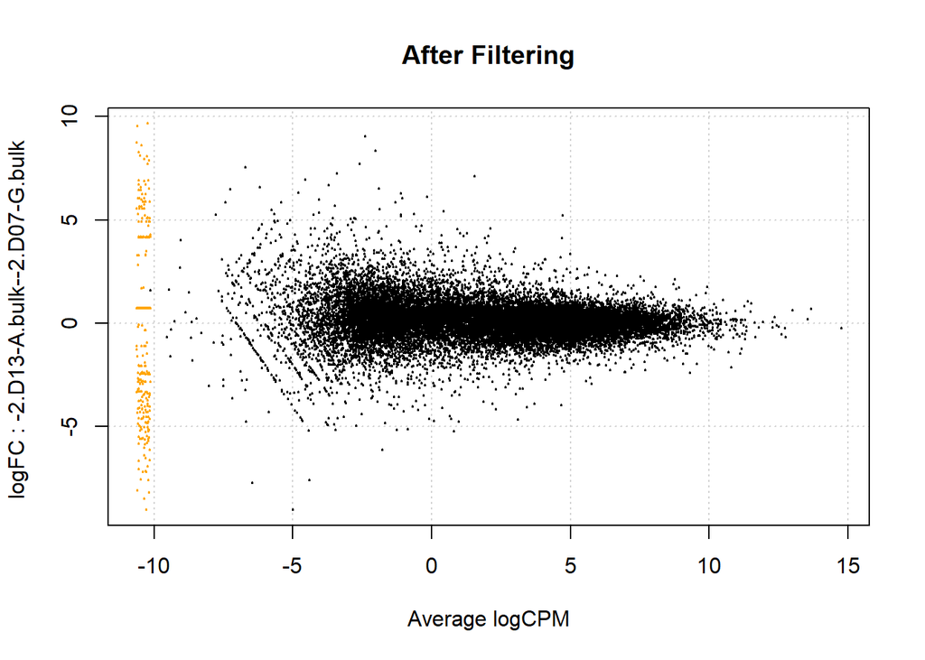

```r
plotSmear(filt_series, main = "After Filtering")
```

Donor vs donor this looks like very nice filtering (above, at any one time point some genes will be missing).

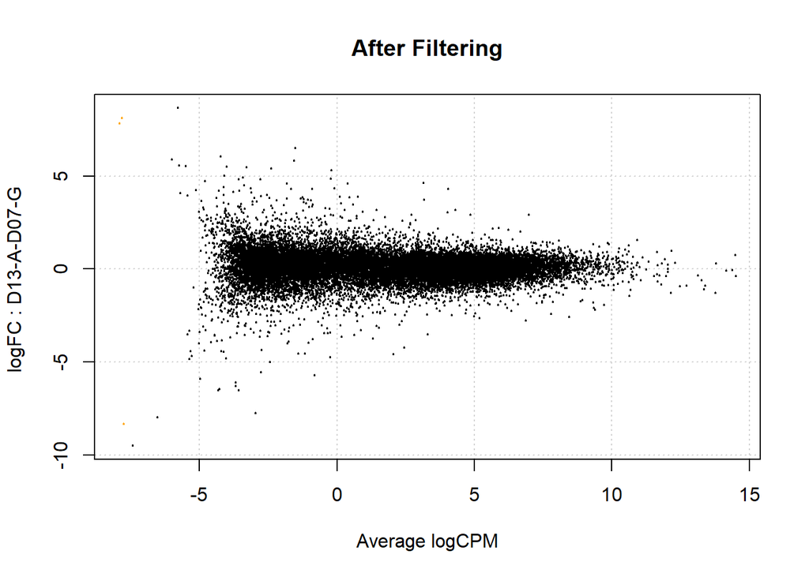

```r
#Plot donor v donor -> a few low exression genes still but predominantly good filtering
two_filt = filt_series
two_filt$samples$group = as.factor(filt_series$samples$donor)
plotSmear(two_filt, main = "After Filtering")
```

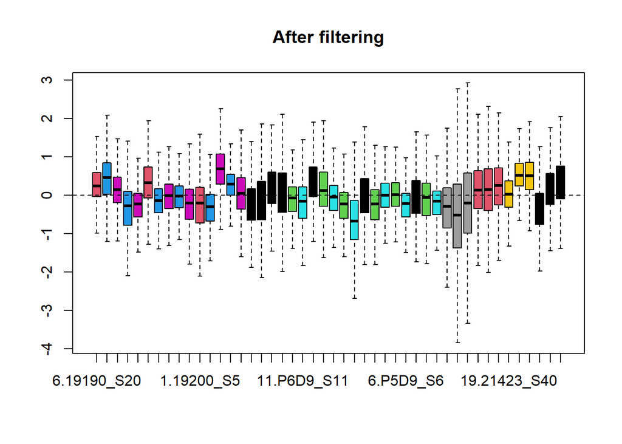

```r
#library sizes are different, but relative log expression is
#now ~ normally distributed within libraries
plotRLE(filt_series$counts, outline=FALSE,
        col=filt_series$samples$group, main="After filtering")
```

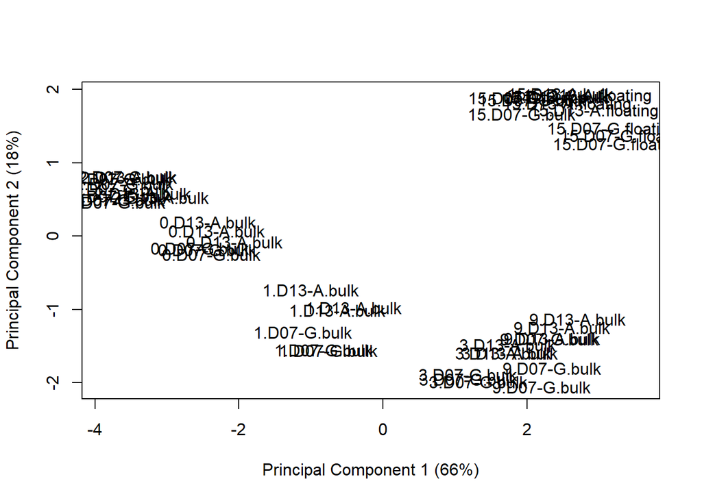

```r
plotMDS(filt_series, labels = filt_series$samples$group, gene.selection = "common")
```

Because we’re mainly interested in days Pro,0, 3 and 15 (bulk) I’m going to create a filter vector that eliminates genes that would drop out if we only used those samples. The limma voom method requires adequate filtering of low counts genes to maintain conservative p-values.

```r
short_ob = series_ob[, series_ob$samples$time %in% c(-2,0,3,15) &
                       series_ob$samples$separation == "bulk"]
short_ob$samples
```

```
##                          group lib.size norm.factors        sample_id time
## 6.19190_S20      -2.D13-A.bulk 43343287            1      6-19190_S20   -2
## 7.19191_S1        0.D13-A.bulk 53954863            1       7-19191_S1    0
## 9.19193_S6        3.D13-A.bulk 27650074            1       9-19193_S6    3
## 11.19195_S12     -2.D13-A.bulk 44069380            1     11-19195_S12   -2
## 12.19196_S15      0.D13-A.bulk 33748947            1     12-19196_S15    0
## 14.19198_S21      3.D13-A.bulk 38990845            1     14-19198_S21    3
## 1.19200_S5       -2.D13-A.bulk 24715231            1       1-19200_S5   -2
## 2.19201_S8        0.D13-A.bulk 25887790            1       2-19201_S8    0
## 4.19203_S14       3.D13-A.bulk 51335376            1      4-19203_S14    3
## 20.S2.KD5NT_S16  -2.D07-G.bulk 28227567            1  20-S2-KD5NT_S16   -2
## 21.S7.KD6NT_S19  -2.D07-G.bulk 30639099            1  21-S7-KD6NT_S19   -2
## 22.S12.KD3NT_S22 -2.D07-G.bulk 39314312            1 22-S12-KD3NT_S22   -2
## 1.KD4NT_S1       -2.D07-G.bulk 40875335            1       1.KD4NT_S1   -2
## 10.P6D3_S10       3.D07-G.bulk 37487858            1      10.P6D3_S10    3
## 12.KD3NT_S12     -2.D07-G.bulk 52250725            1     12.KD3NT_S12   -2
## 13.P8D0_S13       0.D07-G.bulk 50473193            1      13.P8D0_S13    0
## 15.P8D3_S15       3.D07-G.bulk 36821008            1      15.P8D3_S15    3
## 2.KD5NT_S2       -2.D07-G.bulk 39256967            1       2.KD5NT_S2   -2
## 3.P5D0_S3         0.D07-G.bulk 35885732            1        3.P5D0_S3    0
## 5.P5D3_S5         3.D07-G.bulk 45252924            1        5.P5D3_S5    3
## 7.KD6NT_S7       -2.D07-G.bulk 37829067            1       7.KD6NT_S7   -2
## 8.P6D0_S8         0.D07-G.bulk 38988386            1        8.P6D0_S8    0
## 19.21423_S40     15.D07-G.bulk 43513597            1     19.21423_S40   15
## 20.21424_S47     15.D07-G.bulk 68529570            1     20.21424_S47   15
## 21.21425_S54     15.D07-G.bulk 67338531            1     21.21425_S54   15
## 22.21426_S3      15.D13-A.bulk 28524813            1      22.21426_S3   15
## 23.21427_S10     15.D13-A.bulk 51405957            1     23.21427_S10   15
## 24.21428_S17     15.D13-A.bulk 52000236            1     24.21428_S17   15
##                  donor biorep    exp construct separation time.donor
## 6.19190_S20      D13-A      7      2    native       bulk   -2.D13-A
## 7.19191_S1       D13-A      7      2    native       bulk    0.D13-A
## 9.19193_S6       D13-A      7      2    native       bulk    3.D13-A
## 11.19195_S12     D13-A      8      2    native       bulk   -2.D13-A
## 12.19196_S15     D13-A      8      2    native       bulk    0.D13-A
## 14.19198_S21     D13-A      8      2    native       bulk    3.D13-A
## 1.19200_S5       D13-A      5      2    native       bulk   -2.D13-A
## 2.19201_S8       D13-A      5      2    native       bulk    0.D13-A
## 4.19203_S14      D13-A      5      2    native       bulk    3.D13-A
## 20.S2.KD5NT_S16  D07-G      5      2    native       bulk   -2.D07-G
## 21.S7.KD6NT_S19  D07-G      6      2    native       bulk   -2.D07-G
## 22.S12.KD3NT_S22 D07-G      8      2    native       bulk   -2.D07-G
## 1.KD4NT_S1       D07-G     P4      1    native       bulk   -2.D07-G
## 10.P6D3_S10      D07-G     P6      1    native       bulk    3.D07-G
## 12.KD3NT_S12     D07-G     P8      1    native       bulk   -2.D07-G
## 13.P8D0_S13      D07-G     P8      1    native       bulk    0.D07-G
## 15.P8D3_S15      D07-G     P8      1    native       bulk    3.D07-G
## 2.KD5NT_S2       D07-G     P5      1    native       bulk   -2.D07-G
## 3.P5D0_S3        D07-G     P5      1    native       bulk    0.D07-G
## 5.P5D3_S5        D07-G     P5      1    native       bulk    3.D07-G
## 7.KD6NT_S7       D07-G     P6      1    native       bulk   -2.D07-G
## 8.P6D0_S8        D07-G     P6      1    native       bulk    0.D07-G
## 19.21423_S40     D07-G     P7 native    native       bulk   15.D07-G
## 20.21424_S47     D07-G   P8_2 native    native       bulk   15.D07-G
## 21.21425_S54     D07-G   P8_1 native    native       bulk   15.D07-G
## 22.21426_S3      D13-A     P7 native    native       bulk   15.D13-A
## 23.21427_S10     D13-A     P6 native    native       bulk   15.D13-A
## 24.21428_S17     D13-A     P7 native    native       bulk   15.D13-A
```

```r
strict_filt_genes = short_ob[filterByExpr(short_ob),, keep.lib.sizes=FALSE]$genes
nrow(strict_filt_genes)
```

```
## [1] 20294
```

## Normalise

```r
filt_series = calcNormFactors(filt_series,method = "TMM")
filt_series$samples$norm.factors
```

```
##  [1] 1.2453986 1.2143882 1.1251972 1.1279211 0.9458408 1.3221194 1.0006546
##  [8] 1.1403460 0.9928426 1.0445386 1.3664858 1.1431916 1.2621681 1.0546902
## [15] 1.0419210 1.2097179 1.3116400 1.2920327 1.1244080 0.9952023 0.7803853
## [22] 1.1123322 0.9314573 1.0344096 0.8685083 0.8944944 1.1077116 0.8561957
## [29] 0.9462983 0.9419903 0.8237695 1.1048732 0.9582887 0.8541723 0.7900871
## [36] 0.6108574 0.6834328 0.8374546 0.7701204 0.8412614 0.9839905 1.0048132
## [43] 1.0123257 0.9974582 0.9286878 1.0430292
```

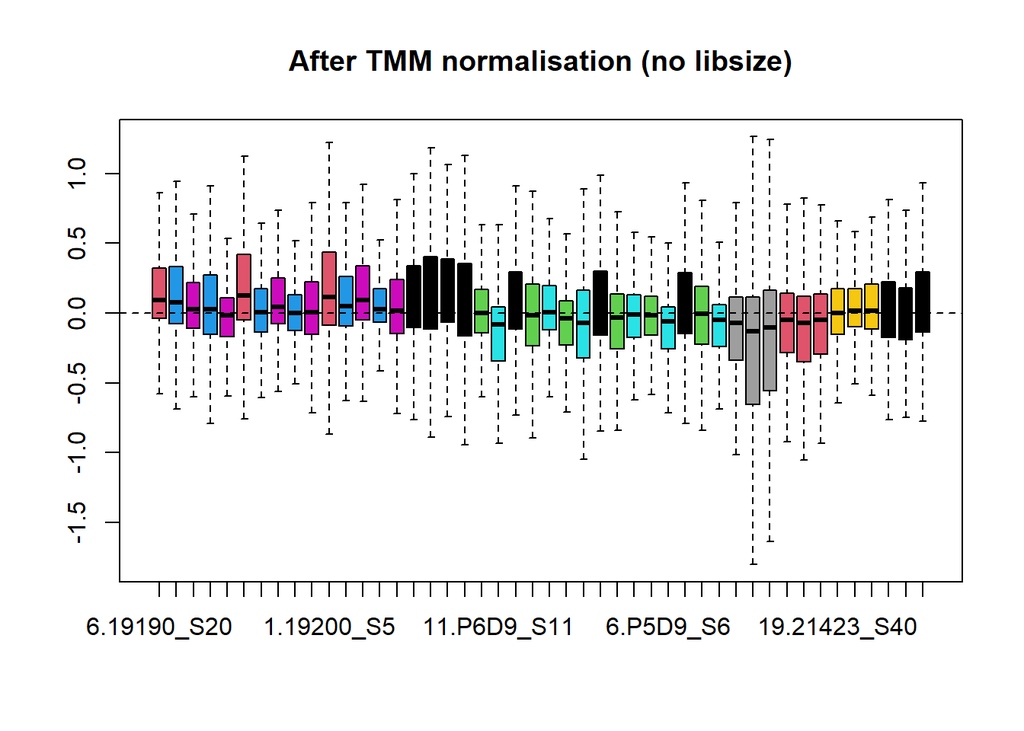

```r
plotRLE(cpm(filt_series$counts), outline=FALSE,
        col=filt_series$samples$group, main="After TMM normalisation (no libsize)")
```

Library size is approximately the same after CPM normalisation, but it still needs to be adjusted directly for library size:

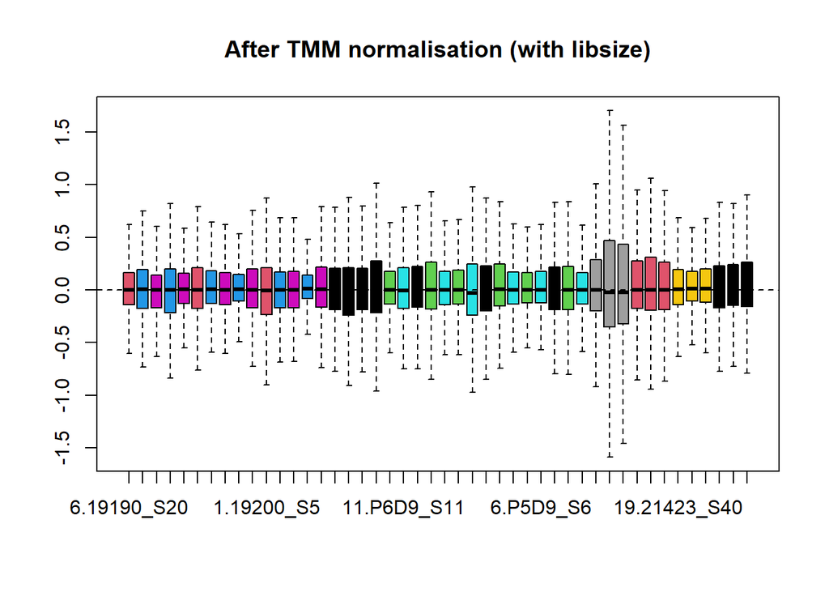

```r
plotRLE(cpm(filt_series, normalized.lib.sizes = TRUE), outline=FALSE,
        col=filt_series$samples$group, main="After TMM normalisation (with libsize)")
```

## Annotate Gene Lists

```r
library(biomaRt)
mart <- biomaRt::useMart(biomart = "ensembl",
  dataset = "hsapiens_gene_ensembl",
   host = "https://jan2019.archive.ensembl.org")
annot = getBM(c("external_gene_name", "description", "ensembl_gene_id"),
              filters = "ensembl_gene_id",
              values = filt_series$genes$Geneid,
              mart = mart)

head(annot, n=2); dim(annot)
```

```
##   external_gene_name                                       description
## 1             TSPAN6 tetraspanin 6 [Source:HGNC Symbol;Acc:HGNC:11858]
## 2               TNMD   tenomodulin [Source:HGNC Symbol;Acc:HGNC:17757]
##   ensembl_gene_id
## 1 ENSG00000000003
## 2 ENSG00000000005
```

```
## [1] 21174     3
```

```r
#Tidying up the annot table
annot$description = gsub("\\[Source:.+\\]", "", annot$description)
colnames(annot)[1] = "gene_name"

#Add gene names to filt_series
filt_series$genes = merge(filt_series$genes, annot, by.x= "Geneid",
                        by.y = "ensembl_gene_id", sort=FALSE)
#head(filt_series$genes)
#make sure length is numeric
filt_series$genes$Length = as.numeric(filt_series$genes$Length)
```

## Limma Log Normalisation

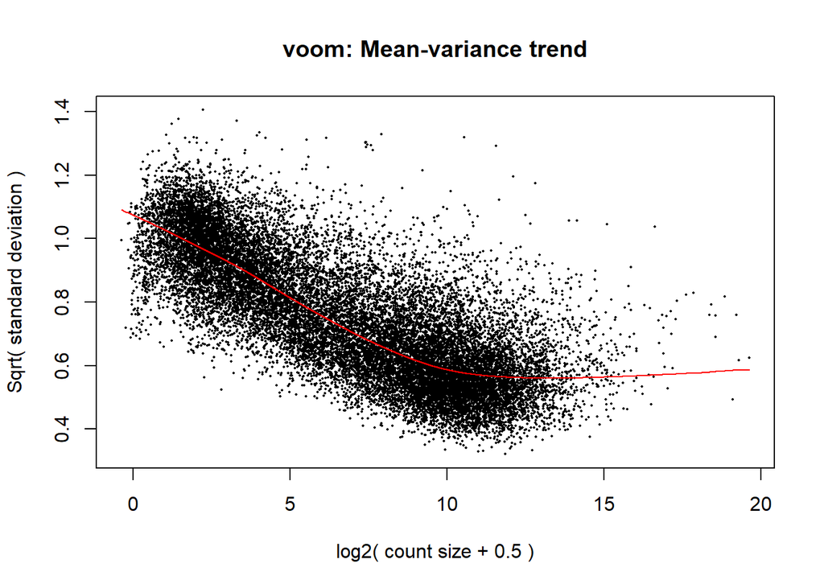

```r
norm_series = voom(filt_series, plot = TRUE)
```

```r
head(norm_series$design, n=2) #groups are time.donor
```

```
##             (Intercept) group-2.D13-A.bulk group0.D07-G.bulk group0.D13-A.bulk
## 6.19190_S20           1                  1                 0                 0
## 7.19191_S1            1                  0                 0                 1
##             group1.D07-G.bulk group1.D13-A.bulk group15.D07-G.bulk
## 6.19190_S20                 0                 0                  0
## 7.19191_S1                  0                 0                  0
##             group15.D07-G.floating group15.D13-A.bulk group15.D13-A.floating
## 6.19190_S20                      0                  0                      0
## 7.19191_S1                       0                  0                      0
##             group3.D07-G.bulk group3.D13-A.bulk group9.D07-G.bulk
## 6.19190_S20                 0                 0                 0
## 7.19191_S1                  0                 0                 0
##             group9.D13-A.bulk
## 6.19190_S20                 0
## 7.19191_S1                  0
```

```r
summary(norm_series$E[,1])#log normlisation min -6, max 14
```

```
##    Min. 1st Qu.  Median    Mean 3rd Qu.    Max.
##  -6.754  -1.468   1.972   1.594   4.635  14.871
```

## Design

How to separate floating and bulk adipocytes? Perhaps I’ll need to run the analysis separately, but start together with the separation as a factor.

```r
#1 check the default design
colnames(norm_series$design)
```

```
##  [1] "(Intercept)"            "group-2.D13-A.bulk"     "group0.D07-G.bulk"
##  [4] "group0.D13-A.bulk"      "group1.D07-G.bulk"      "group1.D13-A.bulk"
##  [7] "group15.D07-G.bulk"     "group15.D07-G.floating" "group15.D13-A.bulk"
## [10] "group15.D13-A.floating" "group3.D07-G.bulk"      "group3.D13-A.bulk"
## [13] "group9.D07-G.bulk"      "group9.D13-A.bulk"
```

```r
head(filt_series$samples, n=2)
```

```
##                     group lib.size norm.factors   sample_id time donor biorep
## 6.19190_S20 -2.D13-A.bulk 43327502     1.245399 6-19190_S20   -2 D13-A      7
## 7.19191_S1   0.D13-A.bulk 53932903     1.214388  7-19191_S1    0 D13-A      7
##             exp construct separation time.donor
## 6.19190_S20   2    native       bulk   -2.D13-A
## 7.19191_S1    2    native       bulk    0.D13-A
```

```r
pair_design = model.matrix(~0+filt_series$samples$group)
colnames(pair_design) = paste("day", gsub("-",".",levels(filt_series$samples$group)), sep="")
rownames(pair_design) = filt_series$samples$sample_id
head(pair_design, n=2)
```

```
##             day.2.D07.G.bulk day.2.D13.A.bulk day0.D07.G.bulk day0.D13.A.bulk
## 6-19190_S20                0                1               0               0
## 7-19191_S1                 0                0               0               1
##             day1.D07.G.bulk day1.D13.A.bulk day15.D07.G.bulk
## 6-19190_S20               0               0                0
## 7-19191_S1                0               0                0
##             day15.D07.G.floating day15.D13.A.bulk day15.D13.A.floating
## 6-19190_S20                    0                0                    0
## 7-19191_S1                     0                0                    0
##             day3.D07.G.bulk day3.D13.A.bulk day9.D07.G.bulk day9.D13.A.bulk
## 6-19190_S20               0               0               0               0
## 7-19191_S1                0               0               0               0
```

## Making a large time based model

Using bulk day15 samples time_effect_donor7 + time_effect_donor13 was the pvalue used at 0.01 to select genes for dpgp

```r
pair_fit = lmFit(norm_series, design=pair_design)

contrasts = makeContrasts(time_effect_donor7 = (day0.D07.G.bulk - day.2.D07.G.bulk ) + #D-2 -> D0 effect
                                                  (day1.D07.G.bulk - day0.D07.G.bulk) + #D0 -> D1 effect
                                                  (day3.D07.G.bulk - day1.D07.G.bulk) + #D1 -> D3 effect
                                                  (day9.D07.G.bulk - day3.D07.G.bulk) + #D3 -> D9 effect
                                                  (day15.D07.G.bulk - day9.D07.G.bulk),
                          time_effect_donor13 = (day0.D13.A.bulk - day.2.D13.A.bulk ) + #D-2 -> D0 effect
                                                  (day1.D13.A.bulk - day0.D13.A.bulk) + #D0 -> D1 effect
                                                  (day3.D13.A.bulk - day1.D13.A.bulk) + #D1 -> D3 effect
                                                  (day9.D13.A.bulk - day3.D13.A.bulk) + #D3 -> D9 effect
                                                  (day15.D13.A.bulk - day9.D13.A.bulk), #D9 -> D15 effect
                          simple_time_effect = (day0.D07.G.bulk - day.2.D07.G.bulk ) + #D-2 -> D0 effect
                                                  (day3.D07.G.bulk - day0.D07.G.bulk) + #D0 -> D3 effect
                                                  (day15.D07.G.bulk - day3.D07.G.bulk) + #D3 -> D15 effect
                                                  (day0.D13.A.bulk - day.2.D13.A.bulk ) + #D-2 -> D0 effect
                                                  (day3.D13.A.bulk - day0.D13.A.bulk) + #D1 -> D3 effect
                                                  (day15.D13.A.bulk - day3.D13.A.bulk), #D9 -> D15 effect
                          #Donor 7 changes over time
                          d.2_to_d0.D7 = day0.D07.G.bulk - day.2.D07.G.bulk,
                          d0_to_d1.D7 = day1.D07.G.bulk - day0.D07.G.bulk,
                          d1_to_d3.D7 = day3.D07.G.bulk - day1.D07.G.bulk,
                          d3_to_d9.D7= day9.D07.G.bulk - day3.D07.G.bulk,
                          d9_to_d15.D7.bulk =  day15.D07.G.bulk - day9.D07.G.bulk,
                          d9_to_d15.D7.floating =  day15.D07.G.floating - day9.D07.G.bulk,
                          d15.bulk_to_floating.D7 = day15.D07.G.floating - day15.D07.G.bulk,
                          #Donor 13 changes over time
                          d.2_to_d0.D13 = day0.D13.A.bulk - day.2.D13.A.bulk,
                          d0_to_d1.D13 = day1.D13.A.bulk - day0.D13.A.bulk,
                          d1_to_d3.D13 = day3.D13.A.bulk - day1.D13.A.bulk,
                          d3_to_d9.D13 = day9.D13.A.bulk - day3.D13.A.bulk,
                          d9_to_d15.D13.bulk =  day15.D13.A.bulk - day9.D13.A.bulk,
                          d9_to_d15.D13.floating =  day15.D13.A.floating - day9.D13.A.bulk,
                          d15.bulk_to_floating.D13 = day15.D13.A.floating - day15.D13.A.bulk,
                          #And the additional timepoints
                          d0_to_d3.D7 =  day3.D07.G.bulk - day0.D07.G.bulk,
                          d0_to_d3.D13 =  day3.D13.A.bulk - day0.D13.A.bulk,
                          d3_to_d15.D7 =  day15.D07.G.bulk - day3.D07.G.bulk,
                          d3_to_d15.D13 =  day15.D13.A.bulk - day3.D13.A.bulk,
                          levels=pair_design)
special_fit = contrasts.fit(pair_fit,contrasts)
special_fit = eBayes(special_fit, robust = TRUE)
```

```r
summary(decideTests(special_fit, method="separate", adjust.method = "BH", p.value = 0.01)) #Adjusted for contrast
```

```
##        time_effect_donor7 time_effect_donor13 simple_time_effect d.2_to_d0.D7
## Down                 4563                4558               5677         2488
## NotSig              11929               12246               9577        15508
## Up                   4682                4370               5920         3178
##        d0_to_d1.D7 d1_to_d3.D7 d3_to_d9.D7 d9_to_d15.D7.bulk
## Down          1437         250         319              3353
## NotSig       18900       20481       20466             14120
## Up             837         443         389              3701
##        d9_to_d15.D7.floating d15.bulk_to_floating.D7 d.2_to_d0.D13 d0_to_d1.D13
## Down                    4357                    3097           909         1301
## NotSig                 12264                   14860         19492        19021
## Up                      4553                    3217           773          852
##        d1_to_d3.D13 d3_to_d9.D13 d9_to_d15.D13.bulk d9_to_d15.D13.floating
## Down            619          178               3067                   3181
## NotSig        19845        20687              15334                  14969
## Up              710          309               2773                   3024
##        d15.bulk_to_floating.D13 d0_to_d3.D7 d0_to_d3.D13 d3_to_d15.D7
## Down                        131        2275         2295         3626
## NotSig                    20871       17367        17103        13821
## Up                          172        1532         1776         3727
##        d3_to_d15.D13
## Down            3120
## NotSig         14923
## Up              3131
```

```r
summary(decideTests(special_fit ,method="global", adjust.method = "BH"), p.value= 0.01) #Unadjusted for contrast
```

```
##        time_effect_donor7 time_effect_donor13 simple_time_effect d.2_to_d0.D7
## Down                 5221                5396               6195         3493
## NotSig              10452               10500               8377        13338
## Up                   5501                5278               6602         4343
##        d0_to_d1.D7 d1_to_d3.D7 d3_to_d9.D7 d9_to_d15.D7.bulk
## Down          2549        1033        1461              4262
## NotSig       16873       19076       18477             12007
## Up            1752        1065        1236              4905
##        d9_to_d15.D7.floating d15.bulk_to_floating.D7 d.2_to_d0.D13 d0_to_d1.D13
## Down                    5132                    4254          1885         2463
## NotSig                 10613                   12585         17453        16828
## Up                      5429                    4335          1836         1883
##        d1_to_d3.D13 d3_to_d9.D13 d9_to_d15.D13.bulk d9_to_d15.D13.floating
## Down           1474          803               4022                   4019
## NotSig        18206        19266              13103                  12956
## Up             1494         1105               4049                   4199
##        d15.bulk_to_floating.D13 d0_to_d3.D7 d0_to_d3.D13 d3_to_d15.D7
## Down                        996        3335         3330         4642
## NotSig                    18822       15386        15140        11762
## Up                         1356        2453         2704         4770
##        d3_to_d15.D13
## Down            4135
## NotSig         12685
## Up              4354
```

Interesting, the time effect is less significant in donor13. The time effect is similar rather than different between donors -> most genes respond similarly to the adipogenic cocktail, regardless of depot/donor. Removing those extra timepoints (Day1, Day9), leads to ~6k genes found both up and down

## Number of DE genes

Adding an extra timepoint adds more genes to the DE list; 11,639 genes at p < 0.01 (basically 50% of all detected genes).

```r
comb = topTable(special_fit, number = nrow(pair_fit$genes), coef = c("time_effect_donor7","time_effect_donor13"))
dim(comb[comb$adj.P.Val < 0.05,]) #More than half of all genes change; most will be the same
```

```
## [1] 14236    10
```

```r
dim(comb[comb$adj.P.Val < 0.01,])
```

```
## [1] 11639    10
```

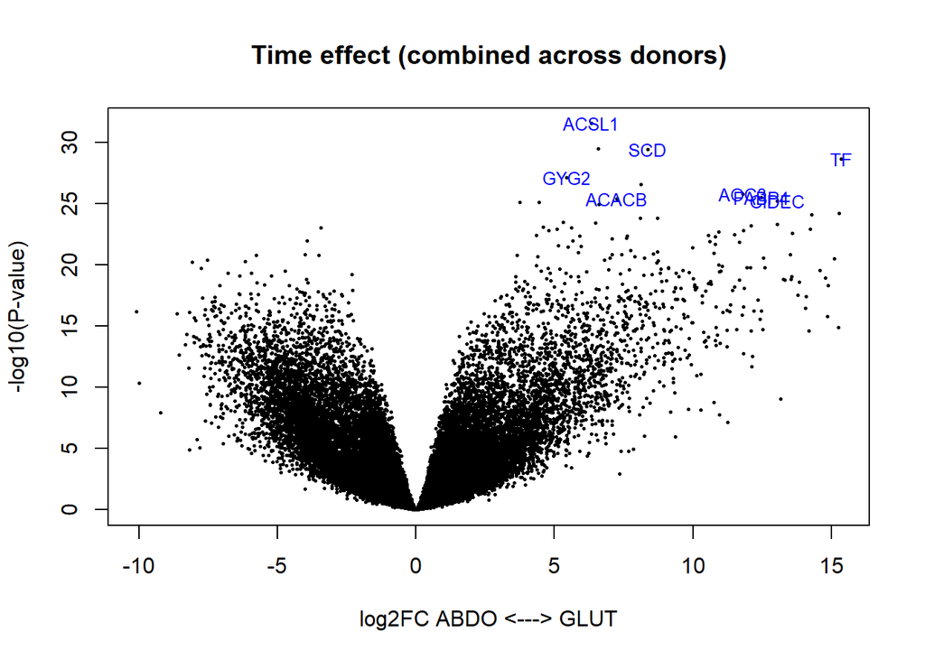

```r
volcanoplot(special_fit, coef = c(1,2), highlight =10, names = special_fit$genes$gene_name,
            main="Time effect (combined across donors)", xlab="log2FC ABDO <---> GLUT")
```

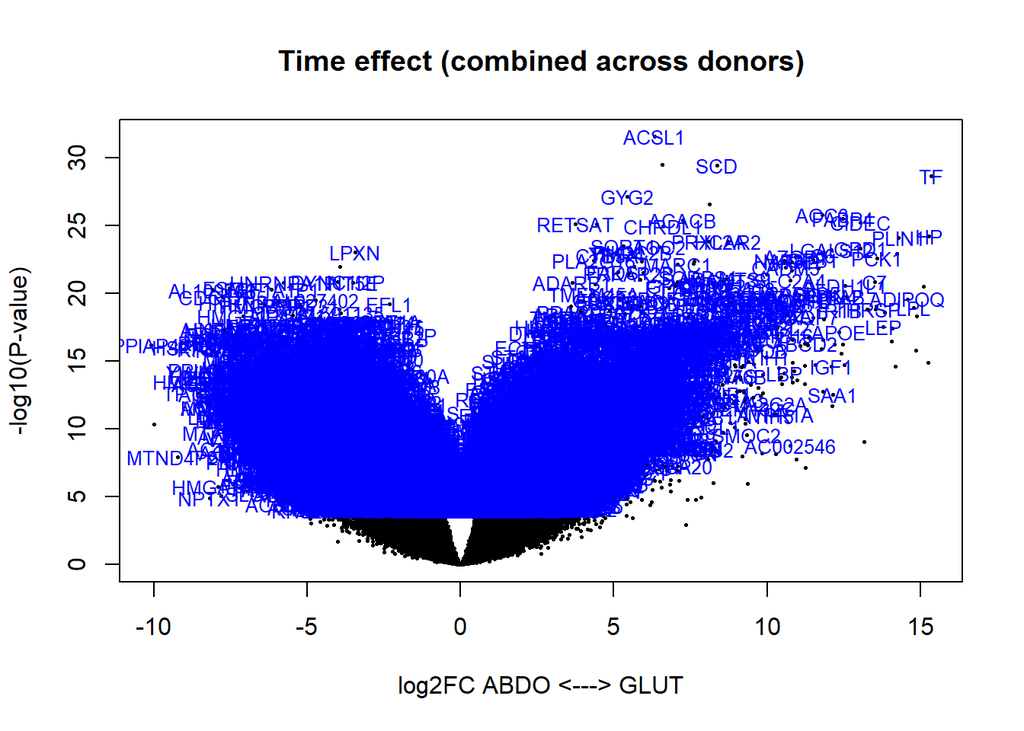

```r
volcanoplot(special_fit, coef = c(1,2), highlight =11639, names = special_fit$genes$gene_name,
            main="Time effect (combined across donors)", xlab="log2FC ABDO <---> GLUT")
```

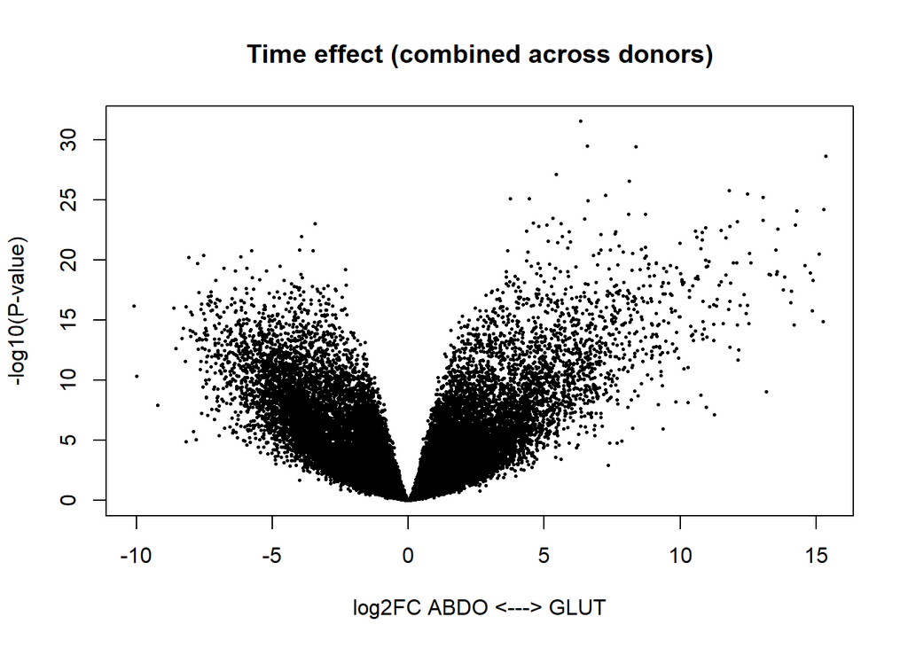

```r
volcanoplot(special_fit, coef = c(1,2),
            main="Time effect (combined across donors)", xlab="log2FC ABDO <---> GLUT")
```

```r
head(comb)
```

```
##                          Geneid Length gene_name
## ENSG00000151726 ENSG00000151726   6284     ACSL1
## ENSG00000099194 ENSG00000099194   5362       SCD
## ENSG00000091513 ENSG00000091513  26199        TF
## ENSG00000056998 ENSG00000056998   3655      GYG2
## ENSG00000042445 ENSG00000042445   4005    RETSAT
## ENSG00000131471 ENSG00000131471   4524      AOC3
##                                                     description
## ENSG00000151726 acyl-CoA synthetase long chain family member 1
## ENSG00000099194                        stearoyl-CoA desaturase
## ENSG00000091513                                    transferrin
## ENSG00000056998                                   glycogenin 2
## ENSG00000042445                               retinol saturase
## ENSG00000131471             amine oxidase, copper containing 3
##                 time_effect_donor7 time_effect_donor13   AveExpr         F
## ENSG00000151726           6.328527            6.587910  8.810891 1311.9218
## ENSG00000099194           8.374125            8.116002 11.807874  977.5321
## ENSG00000091513          15.353000           14.232266  3.105257  772.2557
## ENSG00000056998           5.435924            4.592658  4.980263  682.1157
## ENSG00000042445           3.744336            4.451633  7.100134  664.3419
## ENSG00000131471          11.794312           11.680727  6.379407  583.7419
##                      P.Value    adj.P.Val
## ENSG00000151726 4.270495e-36 9.042346e-32
## ENSG00000099194 1.365663e-33 1.445828e-29
## ENSG00000091513 1.129907e-31 7.974881e-28
## ENSG00000056998 9.517809e-31 5.038252e-27
## ENSG00000042445 1.558726e-30 6.600891e-27
## ENSG00000131471 2.067426e-29 6.789009e-26
```

```r
nuc = topTable(special_fit, number = nrow(pair_fit$genes), coef = "simple_time_effect")
dim(nuc[nuc$adj.P.Val < 0.05,]) #More than half of all genes change; most will be the same
```

```
## [1] 13727    10
```

```r
dim(nuc[nuc$adj.P.Val < 0.01,])
```

```
## [1] 11597    10
```

```r
nuc = nuc[nuc$Geneid %in% strict_filt_genes$Geneid,] #We can filter out ~450 genes with low expression but "significant" at these timepoints
nrow(nuc)
```

```
## [1] 20294
```

```r
head(nuc)
```

```
##                          Geneid Length gene_name
## ENSG00000151726 ENSG00000151726   6284     ACSL1
## ENSG00000099194 ENSG00000099194   5362       SCD
## ENSG00000042445 ENSG00000042445   4005    RETSAT
## ENSG00000056998 ENSG00000056998   3655      GYG2
## ENSG00000076555 ENSG00000076555  14505     ACACB
## ENSG00000101938 ENSG00000101938   3920    CHRDL1
##                                                     description     logFC
## ENSG00000151726 acyl-CoA synthetase long chain family member 1  12.916437
## ENSG00000099194                        stearoyl-CoA desaturase  16.490127
## ENSG00000042445                               retinol saturase   8.195969
## ENSG00000056998                                   glycogenin 2  10.028582
## ENSG00000076555                    acetyl-CoA carboxylase beta  14.871196
## ENSG00000101938                                 chordin like 1  14.207558
##                   AveExpr        t      P.Value    adj.P.Val        B
## ENSG00000151726  8.810891 50.67109 8.291573e-37 1.755658e-32 68.92777
## ENSG00000099194 11.807874 43.63796 2.894826e-34 3.064753e-30 64.45893
## ENSG00000042445  7.100134 36.32084 2.309566e-31 9.780550e-28 59.33469
## ENSG00000056998  4.980263 36.39858 2.132181e-31 9.780550e-28 58.60025
## ENSG00000076555  7.351638 33.29380 7.033854e-30 2.472502e-26 55.41545
## ENSG00000101938  5.954537 32.38457 1.960109e-29 4.611483e-26 54.48275
```

```r
write.table(nuc,  sep="\t", row.names=FALSE,
            file.path(file.path(ous_dir,"Feb22_RNAseq/03limma" , "nucleolus_adipogenesis_DE.tab"))
```

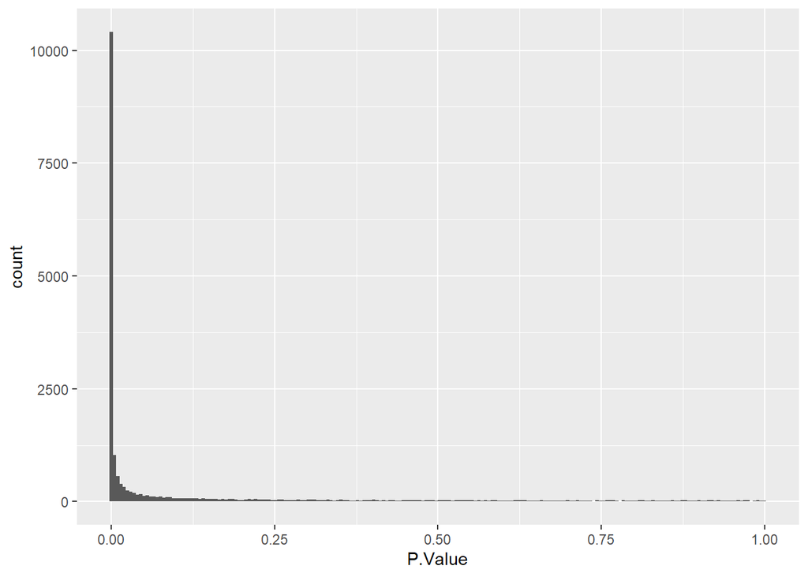

```r
ggplot(nuc) + geom_histogram(aes(x=P.Value), bins=200)
```

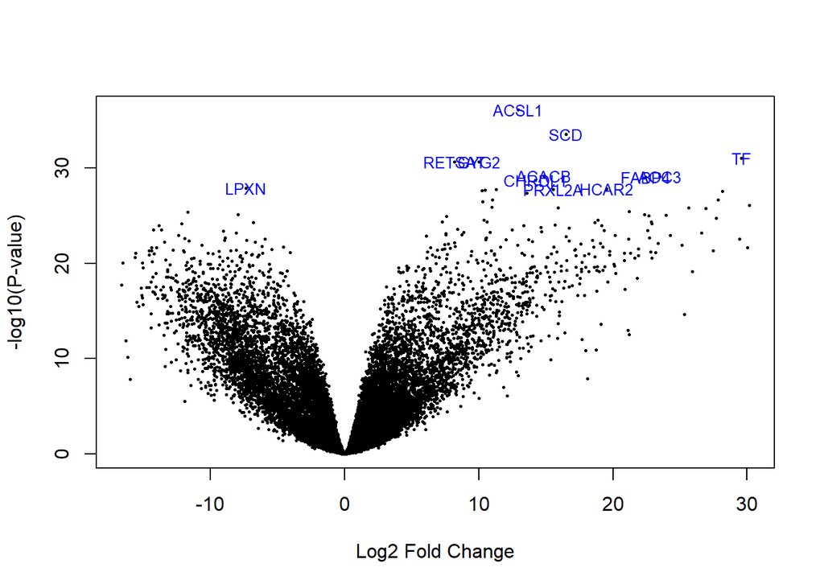

```r
volcanoplot(special_fit, coef="simple_time_effect", highlight = 12, names = special_fit$genes$gene_name)
```

## Venn diagram of new and old lists

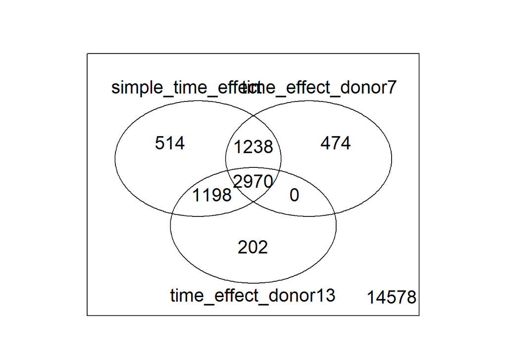

```r
res = decideTests(special_fit, method="separate", adjust.method = "BH", p.value = 0.01) #Adjusted for contrast

vennDiagram(res[,c("simple_time_effect","time_effect_donor7", "time_effect_donor13")], include="up")
```

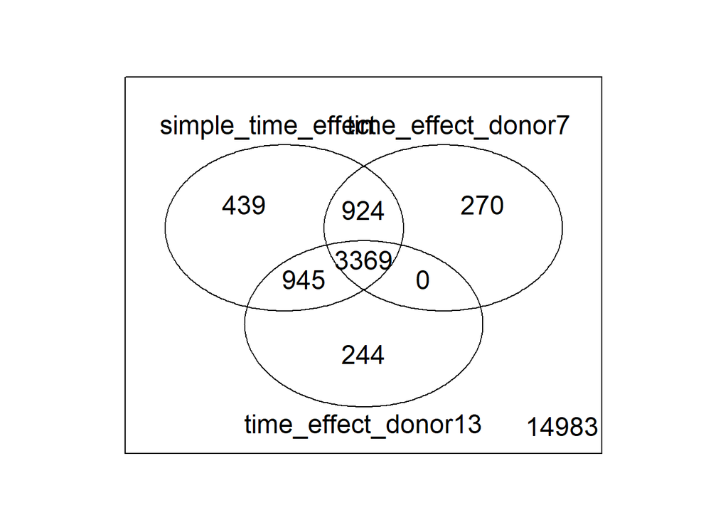

```r
vennDiagram(res[,c("simple_time_effect","time_effect_donor7", "time_effect_donor13")], include="down")
```

Okay, so there’s about 500 unique genes is either direction discovered by this test (as opposed to the d1->d3->d9 tests). We lose about the same number from either donor, but none that were in common between the donors, which seems promising. It seems that we capture the bulk of the adipogenic changes with just timepoints Pro, 0, 3 and 15 :)